# Tercera sesion: Probabilidad clasica y probabilidad condicional - lab B

#simulacion

Se lanzan 2 dados y la suma sea 8

```r
n = 1000
xs = numeric(n)
for(i in 1:n){
#realiza el lanzamiento de dados
  trial = sample(1:6,2, replace = TRUE)
#la suma sea igual a 8
  if(sum(trial) == 8)
    xs[i] = 1
  else
    xs[i] = 0
}
#62 26 35 53 44
#A: es suma
#p()
#el verdadero valor es igual a 0.16666667
mean(xs)
```

```
[1] 0.144
```

por medio del siguiente grafico se muestra la evolucion de **P(A)** en diferentes lanzamientos

[figure not shown]

```r
plot(1:n , cumsum(xs)/1:n , col="red" , type='l' , xlab = "Numero de lanzamientos" , ylab = "Probabilidad " , las=1)
#aidicionando la recta horizontal que indica la probabilidad teorica
abline(h=5/36 , col="blue" , lwd=1.5)
```

# Problema de nacimientos

Para programar cantidades grandes de los factoriales, una recomendacion es usar logaritmo neperiano. Usar el comando “lfactorial” proporciona el logaritmo natural del factorial

```r
  #?lfactorial
n=60
px = numeric(n)
for(i in 1:n){
  aux = lfactorial(365) - lfactorial(365 - i) - i*log(365)
  px[i] = 1 - exp(aux)
}
cbind(1:n,round(px,3))
```

```
      [,1]  [,2]
 [1,]    1 0.000
 [2,]    2 0.003
 [3,]    3 0.008
 [4,]    4 0.016
 [5,]    5 0.027
 [6,]    6 0.040
 [7,]    7 0.056
 [8,]    8 0.074
 [9,]    9 0.095
[10,]   10 0.117
[11,]   11 0.141
[12,]   12 0.167
[13,]   13 0.194
[14,]   14 0.223
```

[output cut: 46 more lines]

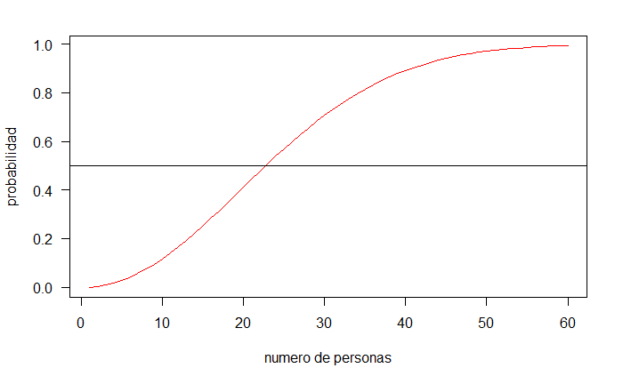

```r
plot(1:n , px , type='l' , las = 1 , xlab="numero de personas" , ylab="probabilidad", col="red")
abline(h=1/2)
```

De una baraja de 52 cartas se seleccionan cartar al azar y a la vez Sea B el evento que la suma de las 3 cartas sea igual 15

```r
n = 3000
xs = numeric(n)
for(i in 1:n){
    #escoger cartas de diferente simbolo
    trial_palos = sample(1:4 , 3 , replace= TRUE )
    #si se llega a escoger del mismo palo entonces no hay repeticion
    if(trial_palos[1] == trial_palos[2])
        trial = sample(1:13 , 3 , replace = FALSE)
    #si los palos son distintos no hay repeticion
    else
      trial = sample(1:13 , 3 , replace = TRUE)
    if(sum(trial) == 15)
      xs[i] = 1
    else       xs[i] = 0
}
mean(xs)
```

```
[1] 0.04333333
```

ploteo

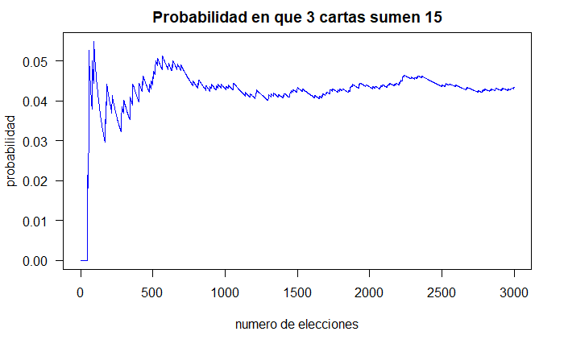

```r
plot(1:n , cumsum(xs)/1:n , col="blue" , type="l" , lwd=1.5 , las=1, xlab="numero de elecciones" , ylab = "probabilidad" , main = "Probabilidad en que 3 cartas sumen 15")
```

#Probabilidad Condicional

```r
n = 100
iter = 0
xs = numeric(n)
while(iter < n){
trial = sample(1:6 , 2 , replace = TRUE)
  if(sum(trial)  == 8){
    exito = if(trial[1] == 2) 1
  else 0
  iter = iter + 1;
  xs[iter]=exito
  }
}

mean(xs)
```

```
[1] 0.25
```

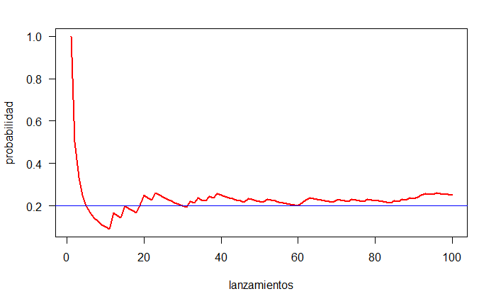

```r
plot(1:n , cumsum(xs)/1:n , type='l' , lwd = 2 , col = "red" , las = 1 , ylab = "probabilidad" , xlab = "lanzamientos")
abline(h=1/5 , col="blue" , lwd=1.5)
```

Se lanza 5 monedas a la vez. calcule la probabilidad de obtener una cara en la primera y tercera moneda dado que el numero total de caras en el lanzamiento es igual a 4. Considere que las monedas son honestas

```r
#1 CARA
#0 SELLO
n = 10000
iter = 0
xs = numeric(n)
while(iter < n){
trial = sample(0:1 , 5 , replace=TRUE)
  if(sum(trial) == 4){
    exito = if(trial[1] == 1 && trial[3] == 1) 1
  else 0
  iter = iter + 1;
  xs[iter] = exito
  }
}
mean(xs)
```

```
[1] 0.6057
```

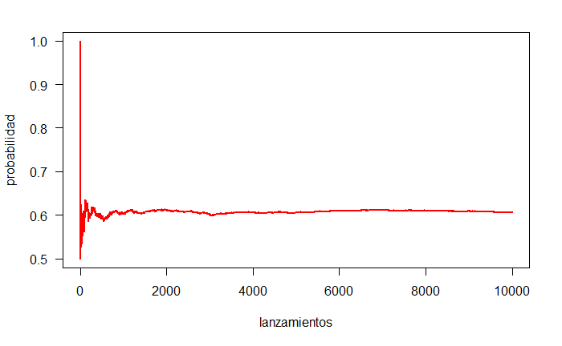

```r
plot(1:n , cumsum(xs)/1:n , type='l' , lwd = 2 , col = "red" , las = 1 , ylab = "probabilidad" , xlab = "lanzamientos")
```

```r
##Variables aleatorios discretas
##En el juego de la ruleta se tiene 38 resultados.En que los 18 primeros numeros son de color rojo, 18 numeros siguientes son de color negro y existen 2 opciones marcadas con 0 y 00

##Valor esperado  de una v.a Discreta
n = 50000
xs = numeric(n)
for(i in 1:n){
  xs[i] = if(sample(1:38,1)<=18) 2 else -2
}
mean(xs)
```

```
[1] -0.1032
```

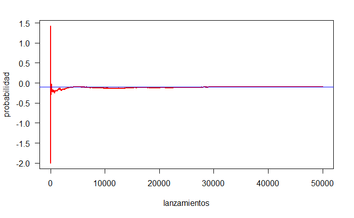

```r
plot(1:n , cumsum(xs)/1:n , type='l' , lwd = 2 , col = "red" , las = 1 , ylab = "probabilidad" , xlab = "lanzamientos")
abline(h=-4/38 , col="blue" , lwd=1.5)
```

Para participar en este juego es necesario pagar 10 soles. El juego consiste en lanzar un dado y observar el resultado ademas

-Si el resultado del dado es 1,2,3 ud pierde 10 soles -Si el resultado del dado es igual a 4,5 entonces se le devuelve los 10 soles -Si el resultado del dado es igual a 6 entonces ud gana 24 soles

Sea W la v.a que representa la ganancia del juego. Calcule el valor esperado

```r
n=50000
xs = numeric(n)
for(i in 1:n){
  trial = sample(1:6 , 1)
  xs[i] = if(trial<= 3) -10
  else if(trial == 4 || trial == 5) 0
  else 14
}
mean(xs)
```

```
[1] -2.66632
```

[figure not shown]

```r
f1 = function(x){
  aux = ((cos(50*x) + sin(10*x))^2)*dunif(x,0,1)
  return(aux);
}
f1(56.9)
```

```
[1] 0
```

```r
integrate(f1,0,1)
```

```
0.9655113 with absolute error < 1.8e-10
```

con el metodo de montecarlo

[figure not shown]

```r
f2 = function(x){
  aux = (0.5*exp(-abs(x)))*dnorm(x,2,2)
  return(aux);
}
```

```r
integrate(f2,-Inf,Inf)
```

```
0.1161786 with absolute error < 6.9e-05
```

```r
n = 10000
x2 = rnorm(x,2,2)
haux = h2(x2)
hbarn = cumsum(haux)/1:n
```

[output not shown]

[figure not shown]

```r
plot(1:n , hbarn , type='l' , lwd=2 , las = 1 , xlab="n" , ylab="E[h(x)]" , ylim= c(0,0.2))
abline(h=0.1161786 , col=2 ,lwd=2)
```